# Part 1 - (Ford GoBike System Data Exploration)

## Introduction

The udacity provided the dataset for exploring Ford GoBike System in this report.The dataset was loaded into juypter notebook using the library pamdas. The main aim of this repoort is to explore the data set using univariate, bivariate and multivariate visualizations which are used to reveal the patterns or relationships of the variables.

## Preliminary Wrangling

```python
# import all packages and set plots to be embedded inline
import numpy as np
import pandas as pd
import matplotlib.pyplot as plt
import seaborn as sb

%matplotlib inline
```

Loading Ford GoBike System Dataset into Juypter notebook and describes its properties.

```python
# loading data into juypter as bike_data
bike_data=pd.read_csv('201902-fordgobike-tripdata.csv')
```

```python
#view the first 10 rows of dataset
bike_data.head(10)
```

|  | duration_sec | start_time | end_time | start_station_id | start_station_name | start_station_latitude | start_station_longitude | end_station_id | end_station_name | end_station_latitude | end_station_longitude | bike_id | user_type | member_birth_year | member_gender | bike_share_for_all_trip |
| --- | --- | --- | --- | --- | --- | --- | --- | --- | --- | --- | --- | --- | --- | --- | --- | --- |
| 0 | 52185 | 2019-02-28 17:32:10.1450 | 2019-03-01 08:01:55.9750 | 21.0 | Montgomery St BART Station (Market St at 2nd St) | 37.789625 | -122.400811 | 13.0 | Commercial St at Montgomery St | 37.794231 | -122.402923 | 4902 | Customer | 1984.0 | Male | No |
| 1 | 42521 | 2019-02-28 18:53:21.7890 | 2019-03-01 06:42:03.0560 | 23.0 | The Embarcadero at Steuart St | 37.791464 | -122.391034 | 81.0 | Berry St at 4th St | 37.775880 | -122.393170 | 2535 | Customer | NaN | NaN | No |
| 2 | 61854 | 2019-02-28 12:13:13.2180 | 2019-03-01 05:24:08.1460 | 86.0 | Market St at Dolores St | 37.769305 | -122.426826 | 3.0 | Powell St BART Station (Market St at 4th St) | 37.786375 | -122.404904 | 5905 | Customer | 1972.0 | Male | No |
| 3 | 36490 | 2019-02-28 17:54:26.0100 | 2019-03-01 04:02:36.8420 | 375.0 | Grove St at Masonic Ave | 37.774836 | -122.446546 | 70.0 | Central Ave at Fell St | 37.773311 | -122.444293 | 6638 | Subscriber | 1989.0 | Other | No |
| 4 | 1585 | 2019-02-28 23:54:18.5490 | 2019-03-01 00:20:44.0740 | 7.0 | Frank H Ogawa Plaza | 37.804562 | -122.271738 | 222.0 | 10th Ave at E 15th St | 37.792714 | -122.248780 | 4898 | Subscriber | 1974.0 | Male | Yes |
| 5 | 1793 | 2019-02-28 23:49:58.6320 | 2019-03-01 00:19:51.7600 | 93.0 | 4th St at Mission Bay Blvd S | 37.770407 | -122.391198 | 323.0 | Broadway at Kearny | 37.798014 | -122.405950 | 5200 | Subscriber | 1959.0 | Male | No |
| 6 | 1147 | 2019-02-28 23:55:35.1040 | 2019-03-01 00:14:42.5880 | 300.0 | Palm St at Willow St | 37.317298 | -121.884995 | 312.0 | San Jose Diridon Station | 37.329732 | -121.901782 | 3803 | Subscriber | 1983.0 | Female | No |
| 7 | 1615 | 2019-02-28 23:41:06.7660 | 2019-03-01 00:08:02.7560 | 10.0 | Washington St at Kearny St | 37.795393 | -122.404770 | 127.0 | Valencia St at 21st St | 37.756708 | -122.421025 | 6329 | Subscriber | 1989.0 | Male | No |
| 8 | 1570 | 2019-02-28 23:41:48.7900 | 2019-03-01 00:07:59.7150 | 10.0 | Washington St at Kearny St | 37.795393 | -122.404770 | 127.0 | Valencia St at 21st St | 37.756708 | -122.421025 | 6548 | Subscriber | 1988.0 | Other | No |
| 9 | 1049 | 2019-02-28 23:49:47.6990 | 2019-03-01 00:07:17.0250 | 19.0 | Post St at Kearny St | 37.788975 | -122.403452 | 121.0 | Mission Playground | 37.759210 | -122.421339 | 6488 | Subscriber | 1992.0 | Male | No |

```python
#View the shape of bike_data dataset
bike_data.shape
```

```
(183412, 16)
```

```python
#view data types and other information of bike_data dataset
bike_data.info()
```

```
<class 'pandas.core.frame.DataFrame'>
RangeIndex: 183412 entries, 0 to 183411
Data columns (total 16 columns):
 #   Column                   Non-Null Count   Dtype
---  ------                   --------------   -----
 0   duration_sec             183412 non-null  int64
 1   start_time               183412 non-null  object
 2   end_time                 183412 non-null  object
 3   start_station_id         183215 non-null  float64
 4   start_station_name       183215 non-null  object
 5   start_station_latitude   183412 non-null  float64
 6   start_station_longitude  183412 non-null  float64
 7   end_station_id           183215 non-null  float64
 8   end_station_name         183215 non-null  object
 9   end_station_latitude     183412 non-null  float64
 10  end_station_longitude    183412 non-null  float64
 11  bike_id                  183412 non-null  int64
 12  user_type                183412 non-null  object
 13  member_birth_year        175147 non-null  float64
 14  member_gender            175147 non-null  object
 15  bike_share_for_all_trip  183412 non-null  object
dtypes: float64(7), int64(2), object(7)
memory usage: 22.4+ MB
```

```python
#views sum of missing values in bike_data
bike_data.isnull().sum()
```

```
duration_sec                  0
start_time                    0
end_time                      0
start_station_id            197
start_station_name          197
start_station_latitude        0
start_station_longitude       0
end_station_id              197
end_station_name            197
end_station_latitude          0
end_station_longitude         0
bike_id                       0
user_type                     0
member_birth_year          8265
member_gender              8265
bike_share_for_all_trip       0
dtype: int64
```

```python
#check the number of duplicates in bike_data
bike_data.duplicated().sum()
```

```
0
```

```python
#check the discriptive statistics of numeric variables in the bike_data
bike_data.describe()
```

|  | duration_sec | start_station_id | start_station_latitude | start_station_longitude | end_station_id | end_station_latitude | end_station_longitude | bike_id | member_birth_year |
| --- | --- | --- | --- | --- | --- | --- | --- | --- | --- |
| count | 183412.000000 | 183215.000000 | 183412.000000 | 183412.000000 | 183215.000000 | 183412.000000 | 183412.000000 | 183412.000000 | 175147.000000 |
| mean | 726.078435 | 138.590427 | 37.771223 | -122.352664 | 136.249123 | 37.771427 | -122.352250 | 4472.906375 | 1984.806437 |
| std | 1794.389780 | 111.778864 | 0.099581 | 0.117097 | 111.515131 | 0.099490 | 0.116673 | 1664.383394 | 10.116689 |
| min | 61.000000 | 3.000000 | 37.317298 | -122.453704 | 3.000000 | 37.317298 | -122.453704 | 11.000000 | 1878.000000 |
| 25% | 325.000000 | 47.000000 | 37.770083 | -122.412408 | 44.000000 | 37.770407 | -122.411726 | 3777.000000 | 1980.000000 |
| 50% | 514.000000 | 104.000000 | 37.780760 | -122.398285 | 100.000000 | 37.781010 | -122.398279 | 4958.000000 | 1987.000000 |
| 75% | 796.000000 | 239.000000 | 37.797280 | -122.286533 | 235.000000 | 37.797320 | -122.288045 | 5502.000000 | 1992.000000 |
| max | 85444.000000 | 398.000000 | 37.880222 | -121.874119 | 398.000000 | 37.880222 | -121.874119 | 6645.000000 | 2001.000000 |

```python
#making the copy of original bike_data dataset
bike_data_copy= bike_data.copy()
```

```python
#drop rows with missing values
bike_data_copy.dropna(inplace=True, axis=0)
```

```python
#check the sum of missing values in bike_data_copy
sum(bike_data_copy.isnull().sum())
```

```
0
```

```python
#Convert the start time, end time columns into datetime.
bike_data_copy['start_time'] = pd.to_datetime(bike_data_copy['start_time'])
bike_data_copy['end_time'] = pd.to_datetime(bike_data_copy['end_time'])
```

```python
#convert start_time and end_time into start_day and end_day
bike_data_copy['start_day'] = bike_data_copy['start_time'].dt.day_name()
bike_data_copy['end_day'] = bike_data_copy['end_time'].dt.day_name()
```

```python
days = ['Monday', 'Tuesday', 'Wednesday', 'Thursday', 'Friday', 'Saturday', 'Sunday']
bike_data_copy['start_day'] = pd.Categorical(bike_data_copy['start_day'], categories=days, ordered=True)
bike_data_copy = bike_data_copy.sort_values('start_day')
```

```python
#Convert start_time and end_time into months.
bike_data_copy['start_month'] = bike_data_copy['start_time'].dt.month_name()
bike_data_copy['end_month'] = bike_data_copy['end_time'].dt.month_name()
```

```python
#convert start_station_id,end_station_id and bike_id of bike_data_copy into strings
bike_data_copy.start_station_id=bike_data_copy.start_station_id.astype(str)
bike_data_copy.end_station_id =bike_data_copy.end_station_id.astype(str)
bike_data_copy.bike_id =bike_data_copy.bike_id.astype(str)
```

```python
# convert seconds  into hours
bike_data_copy['duration_hours'] = bike_data_copy['duration_sec'] /3600
```

```python
#values count of the member_birth_year.
bike_data_copy['member_birth_year'].value_counts()
```

```
1988.0    10214
1993.0     9323
1989.0     8967
1990.0     8640
1991.0     8484
          ...
1878.0        1
1910.0        1
1927.0        1
1930.0        1
1928.0        1
Name: member_birth_year, Length: 75, dtype: int64
```

```python
#Replace 1878 with 1978 to be realistics.
bike_data_copy.replace(1878, 1978, inplace=True)
```

```python
# creating the column for age of the participants
bike_data_copy['participant_age']=(2019-bike_data_copy.member_birth_year)
```

```python
#check the information of dataset after preliminarly data wrangling.
bike_data_copy.info()
```

```
<class 'pandas.core.frame.DataFrame'>
Int64Index: 174952 entries, 82681 to 173826
Data columns (total 22 columns):
 #   Column                   Non-Null Count   Dtype
---  ------                   --------------   -----
 0   duration_sec             174952 non-null  int64
 1   start_time               174952 non-null  datetime64[ns]
 2   end_time                 174952 non-null  datetime64[ns]
 3   start_station_id         174952 non-null  object
 4   start_station_name       174952 non-null  object
 5   start_station_latitude   174952 non-null  float64
 6   start_station_longitude  174952 non-null  float64
 7   end_station_id           174952 non-null  object
 8   end_station_name         174952 non-null  object
 9   end_station_latitude     174952 non-null  float64
 10  end_station_longitude    174952 non-null  float64
 11  bike_id                  174952 non-null  object
 12  user_type                174952 non-null  object
 13  member_birth_year        174952 non-null  float64
 14  member_gender            174952 non-null  object
 15  bike_share_for_all_trip  174952 non-null  object
 16  start_day                174952 non-null  category
 17  end_day                  174952 non-null  object
 18  start_month              174952 non-null  object
 19  end_month                174952 non-null  object
 20  duration_hours           174952 non-null  float64
 21  participant_age          174952 non-null  float64
dtypes: category(1), datetime64[ns](2), float64(7), int64(1), object(11)
memory usage: 29.5+ MB
```

### What is/are the main feature(s) of interest in your dataset?

**The main features of interest for this dataset are:**

- To find the average of time for the trips
- To find out wether the average times taken in the trip is affected by the member_gender,user_type and member_birth_year

### What features in the dataset do you think will help support your investigation into your feature(s) of interest?

**The following are the features that will support in my investigation:**

- duration_sec
- user_type
- member_birth_year
- member_gender
- bike_share_for_all_trip

## Univariate Exploration

```python
#create a functions that will apply to all plot for xlabel, ylabel and title
def a_b_c(Alab, Blab, title):
    plt.title(title)
    plt.xlabel(Alab)
    plt.ylabel(Blab)
```

**The distribution of duration_sec**

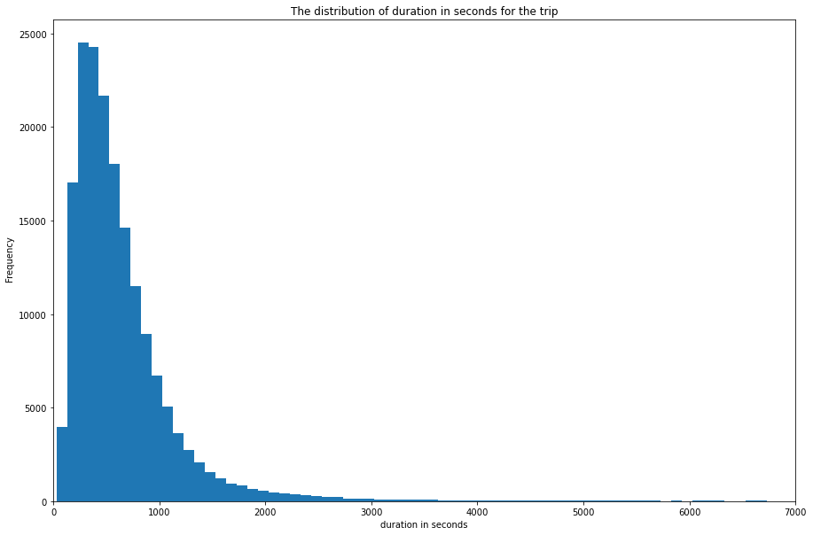

```python
#histogram for the distribution of duration_sec
bins= np.arange(30, bike_data_copy['duration_sec'].max()+150, 100)
plt.figure(figsize=(15, 10))
plt.hist(data=bike_data_copy, x = 'duration_sec', bins=bins)
plt.xlim(0, 7000)
a_b_c('duration in seconds',' Frequency', 'The distribution of duration in seconds for the trip')
plt.show()
```

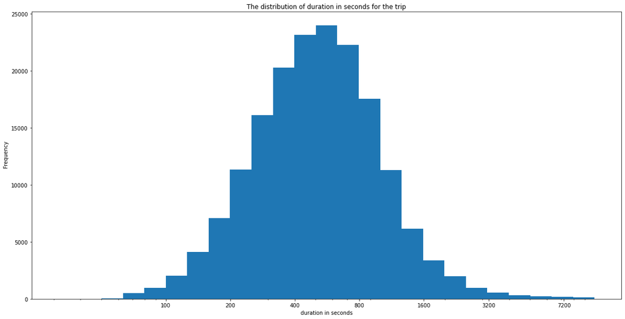

```python
# Since the graph has log tail, we transform using log transformation to understand data easily.
plt.figure(figsize=(20, 10))
bins = 10**np.arange(1.5,  4+0.1 , 0.1)
plt.hist(data = bike_data_copy , x = 'duration_sec' , bins = bins);
plt.xscale('log');
plt.xticks([100, 200, 400, 800, 1600, 3200, 7200],[100, 200, 400, 800, 1600, 3200, 7200])
a_b_c('duration in seconds',' Frequency', 'The distribution of duration in seconds for the trip');
```

In the first histogram of time (duration_sec), the disitribution of time (duration_sec) is positively skewed. It indicates that many participants spent lesser time while few particiants spent longer time. After, transforming durations_sec into log scale, the shape of the histogram became symmentric, hence, the distribution of time is normal with peak lying within 400 and 800.

**The distribution of participants_age**

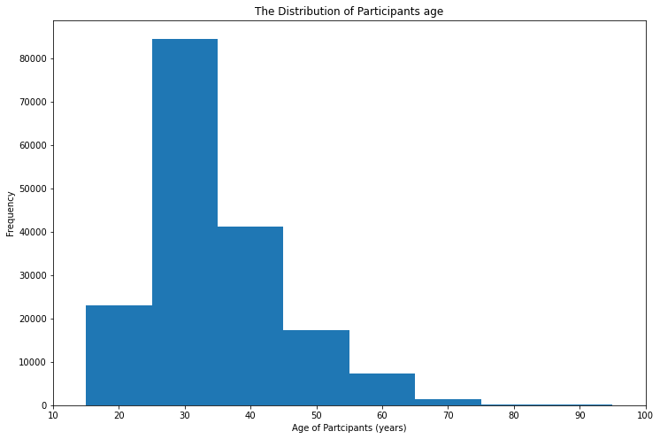

```python
#histogram of participants age
bin1 = np.arange(15,130+10, 10 )
plt.figure(figsize=(12, 8))
plt.hist(data=bike_data_copy, x = 'participant_age', bins=bin1)
plt.xlim(10,100)
#add xlabel, ylabel and title
a_b_c('Age of Partcipants (years)', 'Frequency', 'The Distribution of Participants age')
plt.show()
```

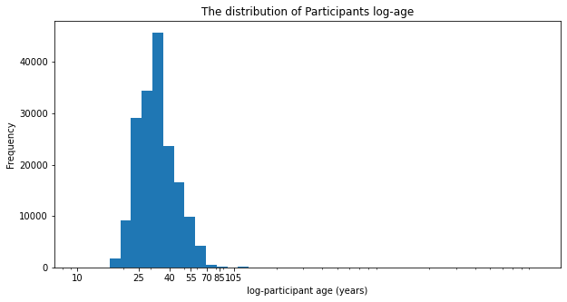

```python
#histogram of participants age after using log scale
bin1 = 10**np.arange(1,4+0.07, 0.07 )
plt.figure(figsize=(10, 5))
plt.hist(data=bike_data_copy, x = 'participant_age', bins=bin1)
ticks=[10,25 , 40, 55, 70, 85,105]
labels = ['{}'.format(m) for m in ticks]
plt.xscale('log')
plt.xticks(ticks,labels)
a_b_c('log-participant age (years)', 'Frequency', 'The distribution of Participants log-age')
plt.show()
```

Based on the first histogram of participants_age, the figure has an assymetric shape. The distribution of age of the participants skewed to the right, thus, many participants are age between 15 to 45 years. However, on the second shape age of the particiapnts which has transformed by log scale, it has a symmentric/unimode shape with the peak between 25 and 40.

**The number of male and female particpated in the Ford GOBike (Gender)**

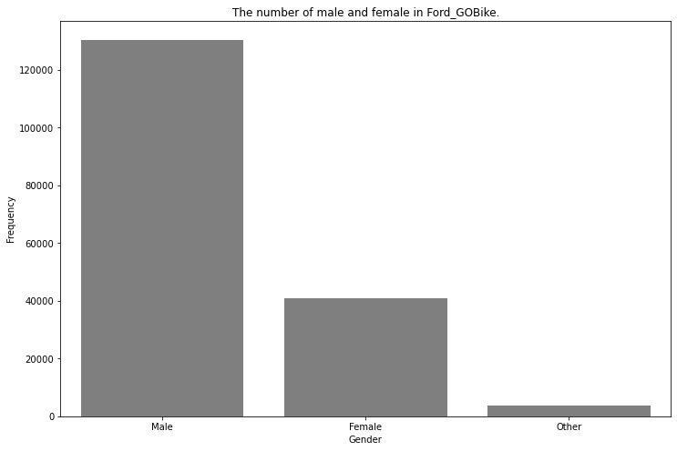

```python
#barch of the gender for bike_data_copy
color = sb.color_palette()[-3]
plt.figure(figsize = [12, 8])
sb.countplot(data=bike_data_copy, x='member_gender', color=color)
a_b_c('Gender', 'Frequency', 'The number of male and female in Ford_GOBike.')
plt.show()
```

According to the bar graph, the gender with the highest participants is male. Fewer number of the participants did not disclose their gender identity are named as the Other.

**The distribution of use_type**

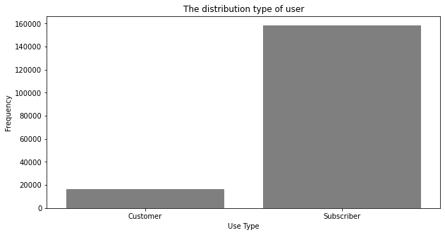

```python
# The bar chart of use_type
color = sb.color_palette()[-3]
plt.figure(figsize = [10, 5])
sb.countplot(data=bike_data_copy, x='user_type', color=color)
a_b_c('Use Type', 'Frequency', 'The distribution type of user')
plt.show()
```

From the above bar graph, most of particpants of Ford GoBike were Subscriber compared to Customer.

**The distribution of start_day and End_day**

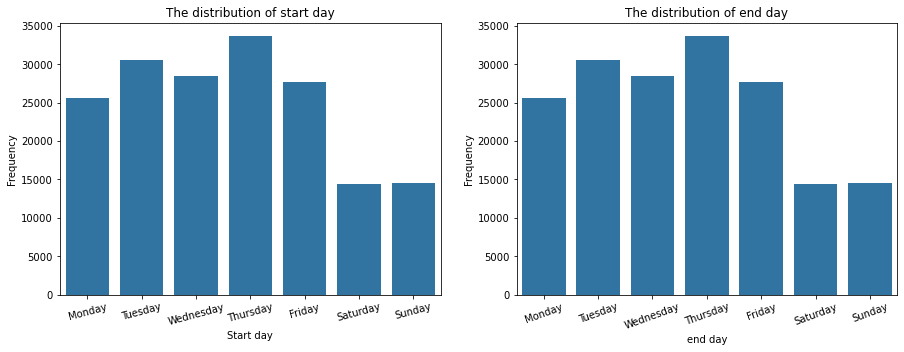

```python
#countplot of Start_day and End_day
color = sb.color_palette()[0]

plt.figure(figsize = [15, 5])
plt.subplot(1,2, 1)
sb.countplot(data=bike_data_copy, x='start_day', color=color)
plt.xticks(rotation = 15)
a_b_c('Start day', 'Frequency', 'The distribution of start day')

plt.subplot(1,2,2)
sb.countplot(data=bike_data_copy, x='end_day', color=color)
plt.xticks(rotation = 20)
a_b_c('end day', 'Frequency', 'The distribution of end day')
plt.show();
```

From the two bar charts, the trends of the trips were similar in the start and end of the days. Thursday have high number of trips in both bar charts. However, Saturday and Sunday have the least number of trips in the two charts.

### Discuss the distribution(s) of your variable(s) of interest. Were there any unusual points? Did you need to perform any transformations?

- In the participant age variable, the distribution was positively skewness. After using log scale for transformations, participants with age above 70 years were considered an outlier in the distribution.
- The distribution of duration in seconds skewed to right. After transformation using log, the distribution was normal (symmetric) with peak found between 400 and 800.

### Of the features you investigated, were there any unusual distributions? Did you perform any operations on the data to tidy, adjust, or change the form of the data? If so, why did you do this?

Based on the distribution of participants' age, the age above 70 years were considered to be outliers because it is not realistic for a person with age above 70 years to rid bike. Therefore, participants with 70 years should be removed from the analysis.

## Bivariate Exploration

**The relationship between gender and user_type**

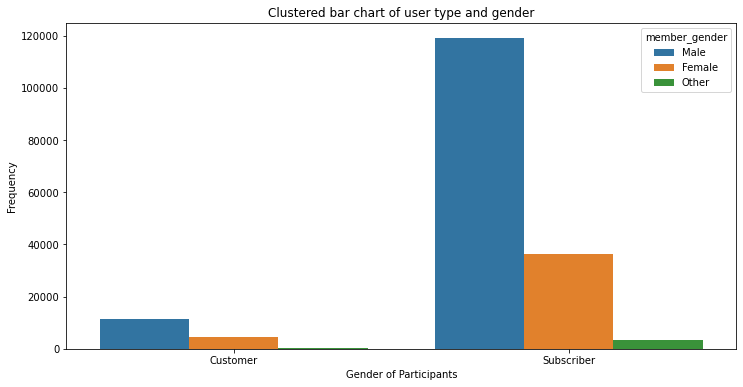

```python
#clustered bar charts for user_type and gender
plt.figure(figsize=(12,6))
sb.countplot(data=bike_data_copy, x ='user_type', hue='member_gender')
a_b_c('Gender of Participants', 'Frequency', 'Clustered bar chart of user type and gender')
plt.show()
```

From the clustered bar chart, it indicate that there is a relationship between user type and gender. For example, males have a higher relationship with user type especially in subscriber than females.

**The relationship between duration time (sec) and the user type**

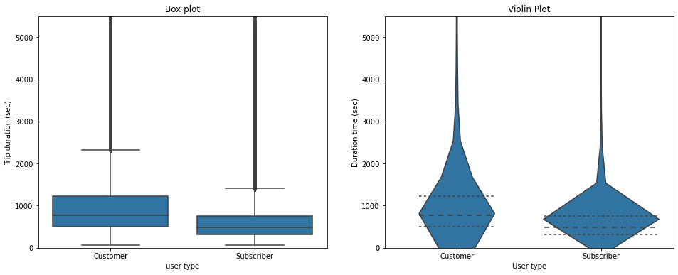

```python
# removing warning by importing libary warnings.
import warnings
warnings.filterwarnings('ignore')
#creating box plot for the relationship between duration_sec and user_type
color=sb.color_palette()[0]
plt.figure(figsize=(16,6))
plt.subplot(1,2,1)
sb.boxplot(data=bike_data_copy, x ='user_type', y='duration_sec', color=color)
a_b_c('user type', 'Trip duration (sec)', 'Box plot')
plt.ylim(0, 5500)

plt.subplot(1,2,2)
sb.violinplot(data=bike_data_copy, x ='user_type', y='duration_sec', color=color, inner='quartile')
a_b_c('User type', 'Duration time (sec)', 'Violin Plot')
plt.ylim(0, 5500)
plt.show()
```

According to the violin and box plots, the customer spend more time to completed their trips compared to the subscriber.

**The relationship between duration time (sec) and bike_share_for_all_trip**

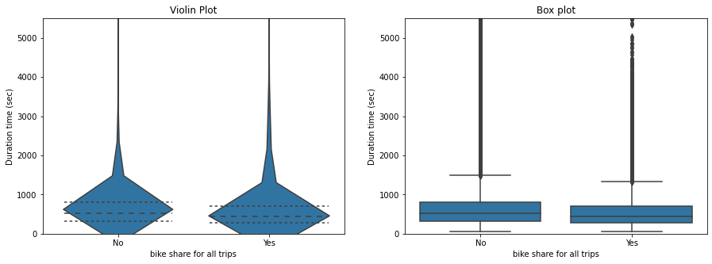

```python
#creating box plot for the relationship between duration time (sec) and bike_share_for_all_trip
color=sb.color_palette()[0]
plt.figure(figsize=(15,5))
plt.subplot(1,2,1)
sb.violinplot(data=bike_data_copy, x ='bike_share_for_all_trip', y='duration_sec', color=color, inner='quartile')
a_b_c('bike share for all trips', 'Duration time (sec)', 'Violin Plot')
plt.ylim(0, 5500)

plt.subplot(1,2,2)
sb.boxplot(data=bike_data_copy, x ='bike_share_for_all_trip', y='duration_sec', color=color)
a_b_c('bike share for all trips', 'Duration time (sec)', 'Box plot')
plt.ylim(0, 5500)
plt.show()
```

Based on the boxplot and violin plot, there is no difference for the user who share bike and the users who dont share for all trips.

**The relationship between duration time (sec) and end_day of trip**

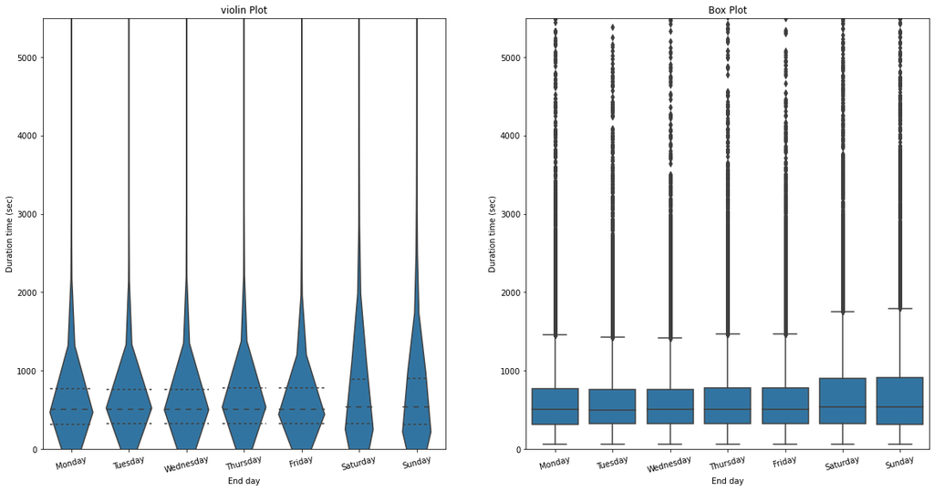

```python
#violin and box plots for the relationship between duration_sec and end_day
plt.figure(figsize=(20,10))
plt.subplot(1,2,1)
sb.violinplot(bike_data_copy['start_day'], bike_data_copy['duration_sec'], color=color, inner='quartile')
plt.xticks(rotation=15)
plt.ylim(0, 5500)
a_b_c('End day', 'Duration time (sec)', 'violin Plot')

plt.subplot(1,2,2)
sb.boxplot(bike_data_copy['end_day'], bike_data_copy['duration_sec'], color=color)
plt.xticks(rotation=15)
plt.ylim(0, 5500)
a_b_c('End day', 'Duration time (sec)', 'Box Plot')

plt.show()
```

From the violin and box plots above, Saturday and Sunday have more durations time at the end day compared to other days of the week.

**The relationship between participants' age and durations times(s) after transformed using log scale and inverse**

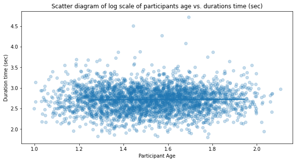

```python
# scatterplot of participants age and durations times after transformed using log scale and inverse.
plt.figure(figsize=(10,5))
df=bike_data_copy.sample(3000, replace=False)
def log(x, inverse=False):
    if not inverse:
        return np.log10(x)
    else:
        return np.power(10, x)
sb.regplot(df['participant_age'].apply(log), df['duration_sec'].apply(log),  scatter_kws={'alpha':1/4}, x_jitter=0.3)
a_b_c('Participant Age', 'Duration time (sec)', 'Scatter diagram of log scale of participants age vs. durations time (sec)')
plt.show()
```

### Were there any interesting or surprising interactions between features?

According to the bivariate explorations, the interataction was found in participant age, durations time (sec), member gender and user_type and member_birth_year. However, there was a weaker relationship between female riders and user type compared to male riders.

## Multivariate Exploration

**The relationship between participants age and duration time (sec) faceted by user type**

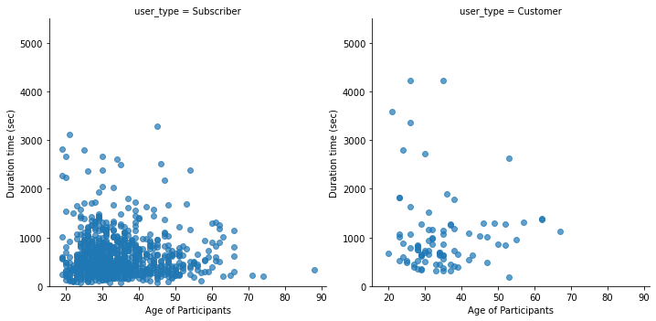

```python
# getting a sample of 1000 from bike_data_copy for scatterplot.
sample_bike_data=bike_data_copy.sample(n=1000, replace = False)
#scatter plot of participants age vs.duration time faceted by user type
graph = sb.FacetGrid(data = sample_bike_data, col = 'user_type', col_wrap=3, size = 5, sharey=False)
graph.map(plt.scatter, 'participant_age', 'duration_sec', alpha =0.7)
graph.set(ylim=(0, 5500))
graph.set(ylabel='Duration time (sec)')
graph.set(xlabel='Age of Participants')
plt.show();
```

**The relationship between participants age and durations time (sec) influenced by user type**

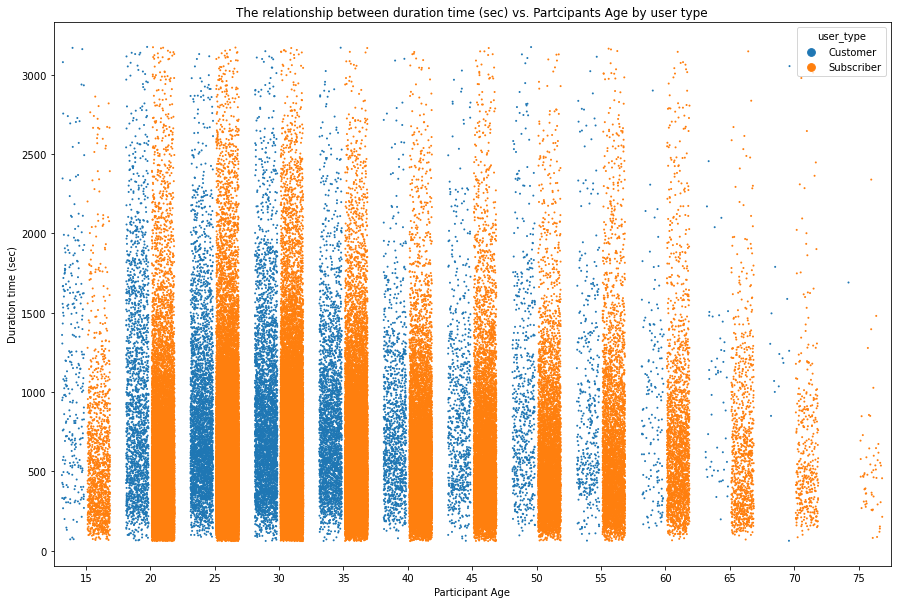

```python
#create age intervals qith 5 years intervals
plt.figure(figsize=(15,10))
bike_data_copy['participant_age_int']=((bike_data_copy['participant_age']//5)*5).astype(int)
sb.stripplot(data=bike_data_copy.query('duration_sec<duration_sec.quantile(0.99) and participant_age<80'),
             x='participant_age_int', y='duration_sec', hue='user_type', size=2, jitter=0.35, dodge=True)
a_b_c('Participant Age', 'Duration time (sec)', 'The relationship between duration time (sec) vs. Partcipants Age by user type')
plt.show();
```

**The relationship between participants age and durations time (sec) influenced by member gender**

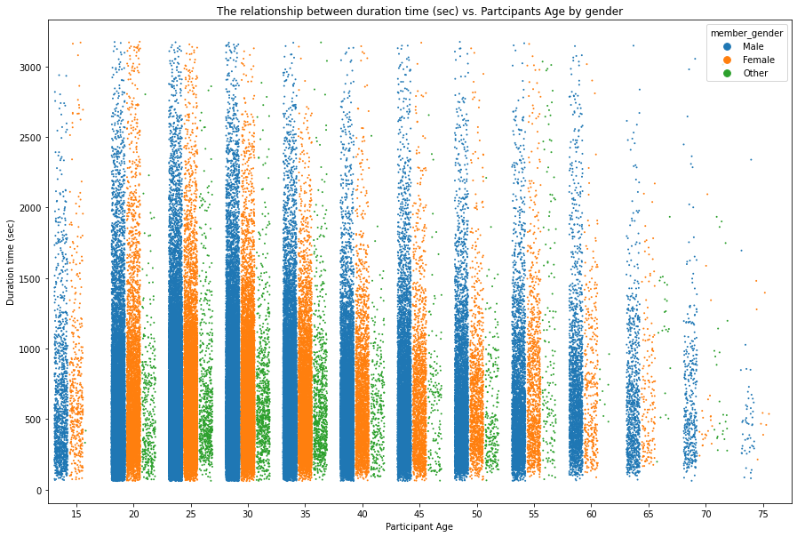

```python
#create age intervals qith 5 years intervals
plt.figure(figsize=(15,10))
bike_data_copy['participant_age_int']=((bike_data_copy['participant_age']//5)*5).astype(int)
sb.stripplot(data=bike_data_copy.query('duration_sec<duration_sec.quantile(0.99) and participant_age<80'),
             x='participant_age_int', y='duration_sec', hue='member_gender', size=2, jitter=0.35, dodge=True)
a_b_c('Participant Age', 'Duration time (sec)', 'The relationship between duration time (sec) vs. Partcipants Age by gender')
plt.show();
```

**The relationship between participants' age and the durations time (sec) by start day**

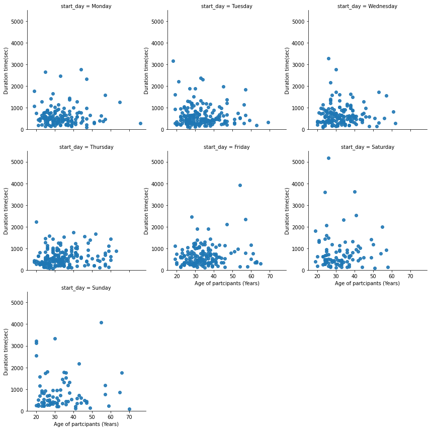

```python
#get a sample of 1000 for visuals from bike_data_copy
sample_bike_data=bike_data_copy.sample(n=1000, replace = False)
#scatter diagram for partcipants' age vs duration time by end day
graph= sb.FacetGrid(data = sample_bike_data, col = 'start_day', size = 4, col_wrap=3, sharey=False)
graph.map(plt.scatter, 'participant_age', 'duration_sec', alpha =0.9)
graph.set(ylim=(0, 5500))
graph.set(ylabel='Duration time(sec)')
graph.set(xlabel='Age of partcipants (Years)')
plt.show()
```